# Retail Sales Data Analysis

Data Analyst

May 27, 2025

## Introduction

This document presents an analysis of retail sales data. The dataset contains information about orders, customers, products, and sales figures from a retail business. The analysis explores sales patterns across different categories, regions, customer segments, and time periods.

## Data Loading and Preprocessing

First, let’s load the data and perform some initial preprocessing.

```r
# Load the data
retail_data <- read.csv("train.csv", stringsAsFactors = FALSE, check.names = FALSE)

# Clean column names (remove BOM character if present)
names(retail_data)[1] <- "Row ID"

# Display the structure of the data
str(retail_data)
```

```
## 'data.frame':    9800 obs. of  18 variables:
##  $ Row ID       : int  1 2 3 4 5 6 7 8 9 10 ...
##  $ Order ID     : chr  "CA-2017-152156" "CA-2017-152156" "CA-2017-138688" "US-2016-108966" ...
##  $ Order Date   : chr  "2017-11-08" "2017-11-08" "2017-06-12" "2016-10-11" ...
##  $ Ship Date    : chr  "2017-11-11" "2017-11-11" "2017-06-16" "2016-10-18" ...
##  $ Ship Mode    : chr  "Second Class" "Second Class" "Second Class" "Standard Class" ...
##  $ Customer ID  : chr  "CG-12520" "CG-12520" "DV-13045" "SO-20335" ...
##  $ Customer Name: chr  "Claire Gute" "Claire Gute" "Darrin Van Huff" "Sean O'Donnell" ...
##  $ Segment      : chr  "Consumer" "Consumer" "Corporate" "Consumer" ...
##  $ Country      : chr  "United States" "United States" "United States" "United States" ...
##  $ City         : chr  "Henderson" "Henderson" "Los Angeles" "Fort Lauderdale" ...
##  $ State        : chr  "Kentucky" "Kentucky" "California" "Florida" ...
##  $ Postal Code  : int  42420 42420 90036 33311 33311 90032 90032 90032 90032 90032 ...
##  $ Region       : chr  "South" "South" "West" "South" ...
##  $ Product ID   : chr  "FUR-BO-10001798" "FUR-CH-10000454" "OFF-LA-10000240" "FUR-TA-10000577" ...
##  $ Category     : chr  "Furniture" "Furniture" "Office Supplies" "Furniture" ...
##  $ Sub-Category : chr  "Bookcases" "Chairs" "Labels" "Tables" ...
##  $ Product Name : chr  "Bush Somerset Collection Bookcase" "Hon Deluxe Fabric Upholstered Stacking Chairs, Rounded Back" "Self-Adhesive Address Labels for Typewriters by Universal" "Bretford CR4500 Series Slim Rectangular Table" ...
##  $ Sales        : num  262 731.9 14.6 957.6 22.4 ...
```

```r
# View the first few rows
head(retail_data) %>%
  kable() %>%
  kable_styling(bootstrap_options = c("striped", "hover", "condensed"), font_size = 11)
```

| Row ID | Order ID | Order Date | Ship Date | Ship Mode | Customer ID | Customer Name | Segment | Country | City | State | Postal Code | Region | Product ID | Category | Sub-Category | Product Name | Sales |
| --- | --- | --- | --- | --- | --- | --- | --- | --- | --- | --- | --- | --- | --- | --- | --- | --- | --- |
| 1 | CA-2017-152156 | 2017-11-08 | 2017-11-11 | Second Class | CG-12520 | Claire Gute | Consumer | United States | Henderson | Kentucky | 42420 | South | FUR-BO-10001798 | Furniture | Bookcases | Bush Somerset Collection Bookcase | 261.9600 |
| 2 | CA-2017-152156 | 2017-11-08 | 2017-11-11 | Second Class | CG-12520 | Claire Gute | Consumer | United States | Henderson | Kentucky | 42420 | South | FUR-CH-10000454 | Furniture | Chairs | Hon Deluxe Fabric Upholstered Stacking Chairs, Rounded Back | 731.9400 |
| 3 | CA-2017-138688 | 2017-06-12 | 2017-06-16 | Second Class | DV-13045 | Darrin Van Huff | Corporate | United States | Los Angeles | California | 90036 | West | OFF-LA-10000240 | Office Supplies | Labels | Self-Adhesive Address Labels for Typewriters by Universal | 14.6200 |
| 4 | US-2016-108966 | 2016-10-11 | 2016-10-18 | Standard Class | SO-20335 | Sean O’Donnell | Consumer | United States | Fort Lauderdale | Florida | 33311 | South | FUR-TA-10000577 | Furniture | Tables | Bretford CR4500 Series Slim Rectangular Table | 957.5775 |
| 5 | US-2016-108966 | 2016-10-11 | 2016-10-18 | Standard Class | SO-20335 | Sean O’Donnell | Consumer | United States | Fort Lauderdale | Florida | 33311 | South | OFF-ST-10000760 | Office Supplies | Storage | Eldon Fold ’N Roll Cart System | 22.3680 |
| 6 | CA-2015-115812 | 2015-06-09 | 2015-06-14 | Standard Class | BH-11710 | Brosina Hoffman | Consumer | United States | Los Angeles | California | 90032 | West | FUR-FU-10001487 | Furniture | Furnishings | Eldon Expressions Wood and Plastic Desk Accessories, Cherry Wood | 48.8600 |

```r
# Check for missing values
missing_values <- colSums(is.na(retail_data))
missing_values[missing_values > 0]
```

```
## Postal Code
##          11
```

### Data Preprocessing

Let’s convert date columns and create additional features for analysis.

```r
# Convert date columns to Date type
retail_data$`Order Date` <- as.Date(retail_data$`Order Date`, format = "%Y-%m-%d")
retail_data$`Ship Date` <- as.Date(retail_data$`Ship Date`, format = "%Y-%m-%d")

# Calculate shipping days
retail_data$`Shipping Days` <- as.numeric(retail_data$`Ship Date` - retail_data$`Order Date`)

# Extract year and month for time-based analysis
retail_data$Year <- year(retail_data$`Order Date`)
retail_data$Month <- month(retail_data$`Order Date`, label = TRUE)
retail_data$YearMonth <- format(retail_data$`Order Date`, "%Y-%m")

# Summary statistics
summary(retail_data[, c("Sales", "Shipping Days", "Year")])
```

```
##      Sales           Shipping Days        Year
##  Min.   :    0.444   Min.   :0.000   Min.   :2015
##  1st Qu.:   17.248   1st Qu.:3.000   1st Qu.:2016
##  Median :   54.490   Median :4.000   Median :2017
##  Mean   :  230.769   Mean   :3.961   Mean   :2017
##  3rd Qu.:  210.605   3rd Qu.:5.000   3rd Qu.:2018
##  Max.   :22638.480   Max.   :7.000   Max.   :2018
```

## Sales Analysis

### Sales by Category

```r
# Total sales by category
sales_by_category <- retail_data %>%
  group_by(Category) %>%
  summarise(
    Total_Sales = sum(Sales, na.rm = TRUE),
    Order_Count = n_distinct(`Order ID`),
    Avg_Order_Value = Total_Sales / Order_Count
  ) %>%
  arrange(desc(Total_Sales))

# Display the results
sales_by_category %>%
  mutate(
    Total_Sales = dollar(Total_Sales),
    Avg_Order_Value = dollar(Avg_Order_Value)
  ) %>%
  kable() %>%
  kable_styling(bootstrap_options = c("striped", "hover"))
```

| Category | Total_Sales | Order_Count | Avg_Order_Value |
| --- | --- | --- | --- |
| Technology | $827,456 | 1519 | $544.74 |
| Furniture | $728,659 | 1727 | $421.92 |
| Office Supplies | $705,422 | 3676 | $191.90 |

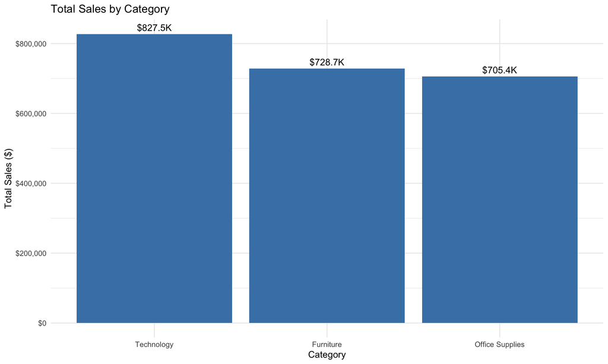

```r
# Visualize
ggplot(sales_by_category, aes(x = reorder(Category, -Total_Sales), y = Total_Sales)) +
  geom_bar(stat = "identity", fill = "steelblue") +
  geom_text(aes(label = sprintf("$%.1fK", Total_Sales/1000)), vjust = -0.5) +
  labs(title = "Total Sales by Category",
       x = "Category",
       y = "Total Sales ($)") +
  theme_minimal() +
  scale_y_continuous(labels = scales::dollar_format())
```

### Sales by Sub-Category

```r
# Sales by sub-category
sales_by_subcategory <- retail_data %>%
  group_by(Category, `Sub-Category`) %>%
  summarise(
    Total_Sales = sum(Sales, na.rm = TRUE),
    Order_Count = n_distinct(`Order ID`)
  ) %>%
  arrange(Category, desc(Total_Sales))

# Display the results
sales_by_subcategory %>%
  mutate(Total_Sales = dollar(Total_Sales)) %>%
  kable() %>%
  kable_styling(bootstrap_options = c("striped", "hover"))
```

| Category | Sub-Category | Total_Sales | Order_Count |
| --- | --- | --- | --- |
| Furniture | Chairs | $322,823 | 566 |
| Furniture | Tables | $202,811 | 302 |
| Furniture | Bookcases | $113,813 | 222 |
| Furniture | Furnishings | $89,212 | 855 |
| Office Supplies | Storage | $219,343 | 764 |
| Office Supplies | Binders | $200,029 | 1291 |
| Office Supplies | Appliances | $104,618 | 444 |
| Office Supplies | Paper | $76,828 | 1163 |
| Office Supplies | Supplies | $46,420 | 181 |
| Office Supplies | Art | $26,705 | 720 |
| Office Supplies | Envelopes | $16,128 | 243 |
| Office Supplies | Labels | $12,348 | 340 |
| Office Supplies | Fasteners | $3,002 | 212 |
| Technology | Phones | $327,782 | 803 |
| Technology | Machines | $189,239 | 112 |
| Technology | Accessories | $164,187 | 702 |
| Technology | Copiers | $146,248 | 66 |

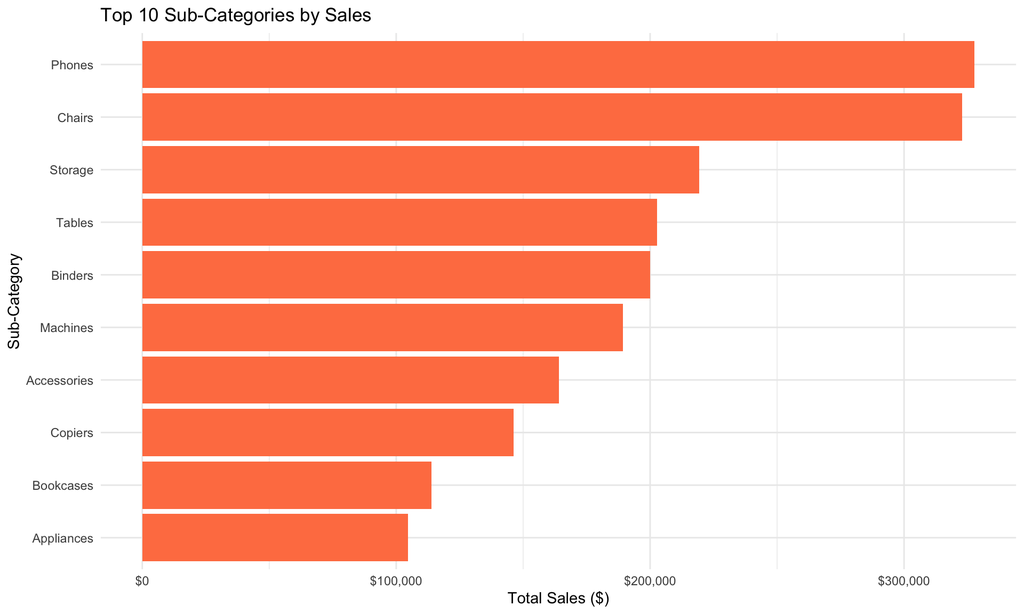

```r
# Visualize top sub-categories
top_subcategories <- retail_data %>%
  group_by(`Sub-Category`) %>%
  summarise(Total_Sales = sum(Sales, na.rm = TRUE)) %>%
  arrange(desc(Total_Sales)) %>%
  head(10)

ggplot(top_subcategories, aes(x = reorder(`Sub-Category`, Total_Sales), y = Total_Sales)) +
  geom_bar(stat = "identity", fill = "coral") +
  coord_flip() +
  labs(title = "Top 10 Sub-Categories by Sales",
       x = "Sub-Category",
       y = "Total Sales ($)") +
  theme_minimal() +
  scale_y_continuous(labels = scales::dollar_format())
```

## Geographic Analysis

### Sales by Region

```r
# Sales by region
sales_by_region <- retail_data %>%
  group_by(Region) %>%
  summarise(
    Total_Sales = sum(Sales, na.rm = TRUE),
    Order_Count = n_distinct(`Order ID`)
  ) %>%
  arrange(desc(Total_Sales))

# Display the results
sales_by_region %>%
  mutate(Total_Sales = dollar(Total_Sales)) %>%
  kable() %>%
  kable_styling(bootstrap_options = c("striped", "hover"))
```

| Region | Total_Sales | Order_Count |
| --- | --- | --- |
| West | $710,220 | 1587 |
| East | $669,519 | 1369 |
| Central | $492,647 | 1156 |
| South | $389,151 | 810 |

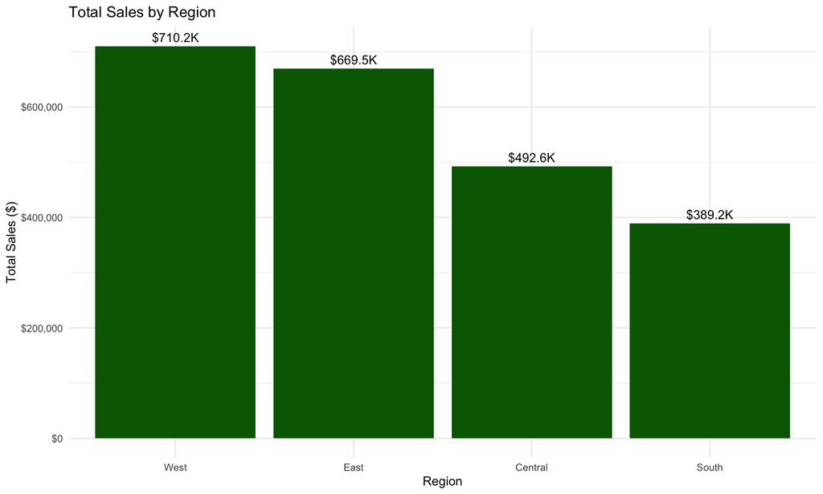

```r
# Visualize
ggplot(sales_by_region, aes(x = reorder(Region, -Total_Sales), y = Total_Sales)) +
  geom_bar(stat = "identity", fill = "darkgreen") +
  geom_text(aes(label = sprintf("$%.1fK", Total_Sales/1000)), vjust = -0.5) +
  labs(title = "Total Sales by Region",
       x = "Region",
       y = "Total Sales ($)") +
  theme_minimal() +
  scale_y_continuous(labels = scales::dollar_format())
```

### Sales by State

```r
# Sales by state
sales_by_state <- retail_data %>%
  group_by(State) %>%
  summarise(
    Total_Sales = sum(Sales, na.rm = TRUE),
    Order_Count = n_distinct(`Order ID`)
  ) %>%
  arrange(desc(Total_Sales))

# Display top 10 states
sales_by_state %>%
  head(10) %>%
  mutate(Total_Sales = dollar(Total_Sales)) %>%
  kable() %>%
  kable_styling(bootstrap_options = c("striped", "hover"))
```

| State | Total_Sales | Order_Count |
| --- | --- | --- |
| California | $446,306 | 1002 |
| New York | $306,361 | 547 |
| Texas | $168,573 | 480 |
| Washington | $135,207 | 254 |
| Pennsylvania | $116,277 | 285 |
| Florida | $88,437 | 197 |
| Illinois | $79,237 | 270 |
| Michigan | $76,136 | 116 |
| Ohio | $75,130 | 227 |
| Virginia | $70,637 | 115 |

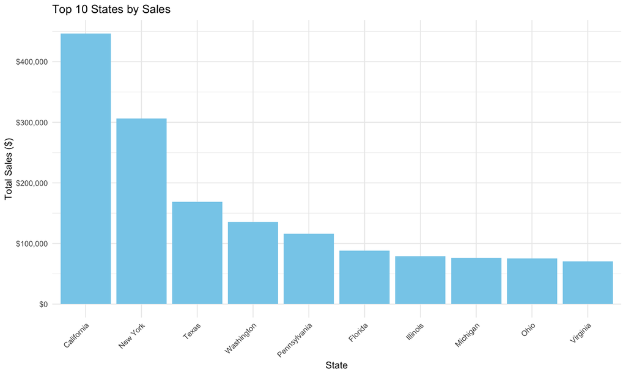

```r
# Visualize top 10 states
ggplot(sales_by_state %>% head(10),
       aes(x = reorder(State, -Total_Sales), y = Total_Sales)) +
  geom_bar(stat = "identity", fill = "skyblue") +
  labs(title = "Top 10 States by Sales",
       x = "State",
       y = "Total Sales ($)") +
  theme_minimal() +
  scale_y_continuous(labels = scales::dollar_format()) +
  theme(axis.text.x = element_text(angle = 45, hjust = 1))
```

## Customer Analysis

### Sales by Customer Segment

```r
# Sales by customer segment
sales_by_segment <- retail_data %>%
  group_by(Segment) %>%
  summarise(
    Total_Sales = sum(Sales, na.rm = TRUE),
    Order_Count = n_distinct(`Order ID`),
    Customer_Count = n_distinct(`Customer ID`),
    Avg_Sales_per_Customer = Total_Sales / Customer_Count
  ) %>%
  arrange(desc(Total_Sales))

# Display the results
sales_by_segment %>%
  mutate(
    Total_Sales = dollar(Total_Sales),
    Avg_Sales_per_Customer = dollar(Avg_Sales_per_Customer)
  ) %>%
  kable() %>%
  kable_styling(bootstrap_options = c("striped", "hover"))
```

| Segment | Total_Sales | Order_Count | Customer_Count | Avg_Sales_per_Customer |
| --- | --- | --- | --- | --- |
| Consumer | $1,148,061 | 2537 | 409 | $2,806.99 |
| Corporate | $688,494 | 1491 | 236 | $2,917.35 |
| Home Office | $424,982 | 894 | 148 | $2,871.50 |

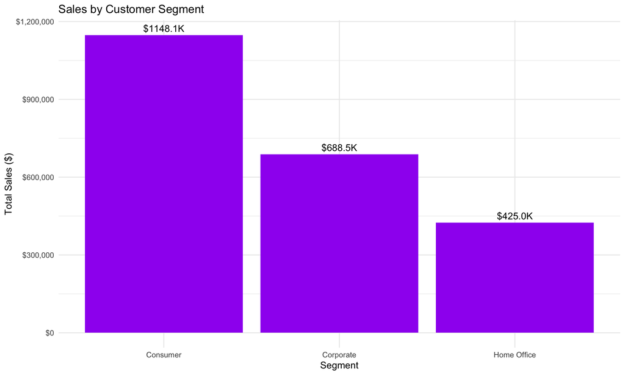

```r
# Visualize
ggplot(sales_by_segment, aes(x = reorder(Segment, -Total_Sales), y = Total_Sales)) +
  geom_bar(stat = "identity", fill = "purple") +
  geom_text(aes(label = sprintf("$%.1fK", Total_Sales/1000)), vjust = -0.5) +
  labs(title = "Sales by Customer Segment",
       x = "Segment",
       y = "Total Sales ($)") +
  theme_minimal() +
  scale_y_continuous(labels = scales::dollar_format())
```

### Top Customers

```r
# Top customers by sales
top_customers <- retail_data %>%
  group_by(`Customer Name`, `Customer ID`) %>%
  summarise(
    Total_Sales = sum(Sales, na.rm = TRUE),
    Order_Count = n_distinct(`Order ID`)
  ) %>%
  arrange(desc(Total_Sales)) %>%
  head(10)

# Display the results
top_customers %>%
  mutate(Total_Sales = dollar(Total_Sales)) %>%
  kable() %>%
  kable_styling(bootstrap_options = c("striped", "hover"))
```

| Customer Name | Customer ID | Total_Sales | Order_Count |
| --- | --- | --- | --- |
| Sean Miller | SM-20320 | $25,043.05 | 5 |
| Tamara Chand | TC-20980 | $19,052.22 | 5 |
| Raymond Buch | RB-19360 | $15,117.34 | 6 |
| Tom Ashbrook | TA-21385 | $14,595.62 | 4 |
| Adrian Barton | AB-10105 | $14,473.57 | 10 |
| Ken Lonsdale | KL-16645 | $14,175.23 | 12 |
| Sanjit Chand | SC-20095 | $14,142.33 | 9 |
| Hunter Lopez | HL-15040 | $12,873.30 | 6 |
| Sanjit Engle | SE-20110 | $12,209.44 | 11 |
| Christopher Conant | CC-12370 | $12,129.07 | 5 |

## Time Series Analysis

### Monthly Sales Trend

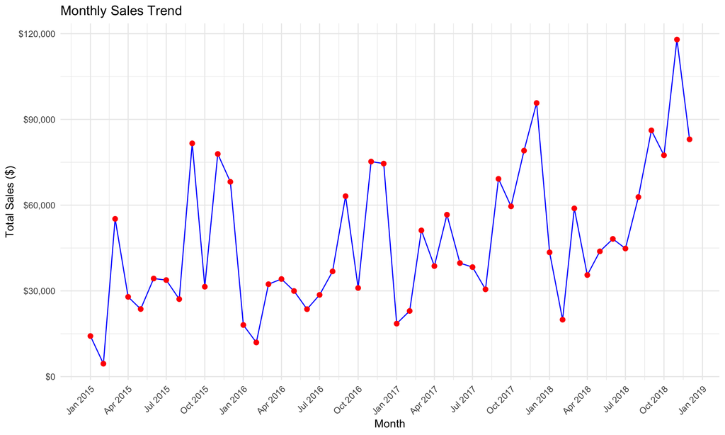

```r
# Monthly sales trend
monthly_sales <- retail_data %>%
  group_by(YearMonth) %>%
  summarise(Total_Sales = sum(Sales, na.rm = TRUE)) %>%
  arrange(YearMonth)

# Convert YearMonth to Date for better plotting
monthly_sales$YearMonth <- as.Date(paste0(monthly_sales$YearMonth, "-01"))

# Visualize
ggplot(monthly_sales, aes(x = YearMonth, y = Total_Sales)) +
  geom_line(color = "blue") +
  geom_point(color = "red", size = 2) +
  labs(title = "Monthly Sales Trend",
       x = "Month",
       y = "Total Sales ($)") +
  theme_minimal() +
  scale_x_date(date_labels = "%b %Y", date_breaks = "3 months") +
  scale_y_continuous(labels = scales::dollar_format()) +
  theme(axis.text.x = element_text(angle = 45, hjust = 1))
```

### Sales by Year and Category

```r
# Sales by year and category
yearly_category_sales <- retail_data %>%
  group_by(Year, Category) %>%
  summarise(Total_Sales = sum(Sales, na.rm = TRUE)) %>%
  arrange(Year, desc(Total_Sales))

# Display the results
yearly_category_sales %>%
  mutate(Total_Sales = dollar(Total_Sales)) %>%
  kable() %>%
  kable_styling(bootstrap_options = c("striped", "hover"))
```

| Year | Category | Total_Sales |
| --- | --- | --- |
| 2015 | Technology | $173,866 |
| 2015 | Furniture | $156,478 |
| 2015 | Office Supplies | $149,513 |
| 2016 | Furniture | $164,054 |
| 2016 | Technology | $162,258 |
| 2016 | Office Supplies | $133,124 |
| 2017 | Technology | $221,962 |
| 2017 | Furniture | $195,813 |
| 2017 | Office Supplies | $182,418 |
| 2018 | Technology | $269,371 |
| 2018 | Office Supplies | $240,368 |
| 2018 | Furniture | $212,314 |

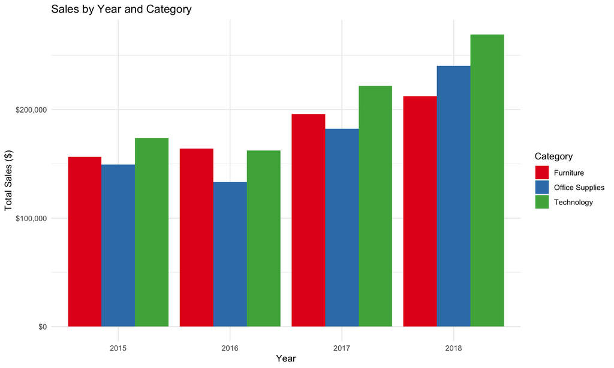

```r
# Visualize
ggplot(yearly_category_sales, aes(x = as.factor(Year), y = Total_Sales, fill = Category)) +
  geom_bar(stat = "identity", position = "dodge") +
  labs(title = "Sales by Year and Category",
       x = "Year",
       y = "Total Sales ($)") +
  theme_minimal() +
  scale_y_continuous(labels = scales::dollar_format()) +
  scale_fill_brewer(palette = "Set1")
```

## Product Analysis

### Top Products

```r
# Product performance
product_performance <- retail_data %>%
  group_by(`Product Name`, `Product ID`, Category, `Sub-Category`) %>%
  summarise(
    Total_Sales = sum(Sales, na.rm = TRUE),
    Order_Count = n()
  ) %>%
  arrange(desc(Total_Sales)) %>%
  head(10)

# Display the results
product_performance %>%
  mutate(Total_Sales = dollar(Total_Sales)) %>%
  kable() %>%
  kable_styling(bootstrap_options = c("striped", "hover"), font_size = 11)
```

| Product Name | Product ID | Category | Sub-Category | Total_Sales | Order_Count |
| --- | --- | --- | --- | --- | --- |
| Canon imageCLASS 2200 Advanced Copier | TEC-CO-10004722 | Technology | Copiers | $61,599.82 | 5 |
| Fellowes PB500 Electric Punch Plastic Comb Binding Machine with Manual Bind | OFF-BI-10003527 | Office Supplies | Binders | $27,453.38 | 10 |
| Cisco TelePresence System EX90 Videoconferencing Unit | TEC-MA-10002412 | Technology | Machines | $22,638.48 | 1 |
| HON 5400 Series Task Chairs for Big and Tall | FUR-CH-10002024 | Furniture | Chairs | $21,870.58 | 8 |
| GBC DocuBind TL300 Electric Binding System | OFF-BI-10001359 | Office Supplies | Binders | $19,823.48 | 11 |
| GBC Ibimaster 500 Manual ProClick Binding System | OFF-BI-10000545 | Office Supplies | Binders | $19,024.50 | 9 |
| Hewlett Packard LaserJet 3310 Copier | TEC-CO-10001449 | Technology | Copiers | $18,839.69 | 8 |
| HP Designjet T520 Inkjet Large Format Printer - 24” Color | TEC-MA-10001127 | Technology | Machines | $18,374.90 | 3 |
| GBC DocuBind P400 Electric Binding System | OFF-BI-10004995 | Office Supplies | Binders | $17,965.07 | 6 |
| High Speed Automatic Electric Letter Opener | OFF-SU-10000151 | Office Supplies | Supplies | $17,030.31 | 3 |

## Shipping Analysis

```r
# Shipping analysis
shipping_summary <- retail_data %>%
  group_by(`Ship Mode`) %>%
  summarise(
    Avg_Shipping_Days = mean(`Shipping Days`, na.rm = TRUE),
    Order_Count = n_distinct(`Order ID`),
    Total_Sales = sum(Sales, na.rm = TRUE)
  ) %>%
  arrange(`Ship Mode`)

# Display the results
shipping_summary %>%
  mutate(
    Total_Sales = dollar(Total_Sales),
    Avg_Shipping_Days = round(Avg_Shipping_Days, 2)
  ) %>%
  kable() %>%
  kable_styling(bootstrap_options = c("striped", "hover"))
```

| Ship Mode | Avg_Shipping_Days | Order_Count | Total_Sales |
| --- | --- | --- | --- |
| First Class | 2.18 | 772 | $345,572 |
| Same Day | 0.04 | 261 | $125,219 |
| Second Class | 3.25 | 944 | $449,914 |
| Standard Class | 5.01 | 2945 | $1,340,831 |

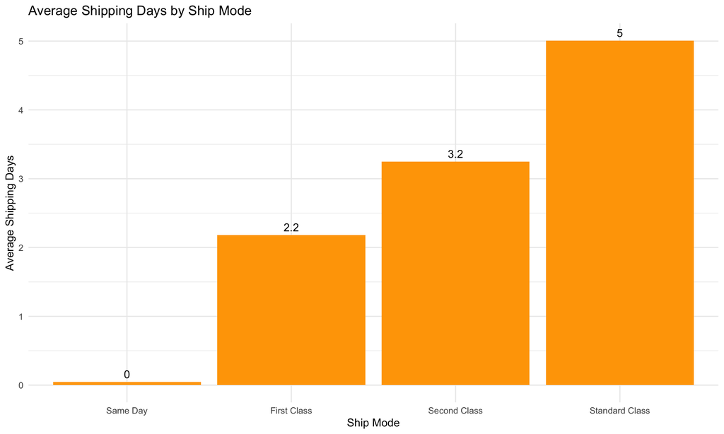

```r
# Visualize
ggplot(shipping_summary, aes(x = reorder(`Ship Mode`, Avg_Shipping_Days),
                            y = Avg_Shipping_Days)) +
  geom_bar(stat = "identity", fill = "orange") +
  geom_text(aes(label = round(Avg_Shipping_Days, 1)), vjust = -0.5) +
  labs(title = "Average Shipping Days by Ship Mode",
       x = "Ship Mode",
       y = "Average Shipping Days") +
  theme_minimal()
```

## Conclusion

This analysis provides insights into the retail sales data across various dimensions:

1. **Product Categories**: Technology products generate the highest sales, followed by Furniture and Office Supplies.
2. **Geographic Distribution**: The West region leads in sales, with California being the top-performing state.
3. **Customer Segments**: The Consumer segment accounts for the largest portion of sales.
4. **Time Trends**: Sales show growth over the years, with some seasonal patterns visible in the monthly data.
5. **Shipping**: Standard Class is the most common shipping mode, while Same Day shipping has the shortest delivery time.

These insights can help inform business decisions related to inventory management, marketing strategies, and customer targeting.

## Next Steps

Potential next steps for further analysis could include:

1. Predictive modeling to forecast future sales
2. Customer segmentation analysis using clustering techniques
3. Market basket analysis to identify product associations
4. Geographic sales analysis with mapping
5. Time series decomposition to identify seasonality and trends